# DSE 511 Final Project Cluster Analysis in R

Cecilia Albert-Black

2025-11-11

Set working directory to R code folder

```r
setwd("C:/Users/q4q/repos/DSE511_Final_Project/Step 3. Cluster Analysis/R Code")
```

Load necessary libraries

```r
library(readr)
library(tidyverse)
library(fitdistrplus)
library(factoextra)
```

Import dataset from Step 1. Data Cleaning

```r
clean_df <- read_csv("C:/Users/q4q/repos/DSE511_Final_Project/Step 1. Data Cleaning/R code/outbreak_clean_r_v2.csv")
head(clean_df)
```

```
## # A tibble: 6 × 30
##    Year Month Date    Season State      State_abbr Primary_mode Setting Etiology
##   <dbl> <dbl> <chr>   <chr>  <chr>      <chr>      <chr>        <chr>   <chr>
## 1  1971     2 1971-02 Winter California CA         Water        Restau… Copper
## 2  1971     6 1971-06 Summer Arkansas   AR         Water        Store   Hepatit…
## 3  1971     6 1971-06 Summer Missouri   MO         Water        Subdiv… Unknown
## 4  1971     6 1971-06 Summer Alabama    AL         Water        Unknown Selenium
## 5  1971     6 1971-06 Summer Vermont    VT         Water        Commun… Unknown
## 6  1971     6 1971-06 Summer Oregon     OR         Water        Restau… Unknown
## # ℹ 21 more variables: Etiology_group <chr>, IFSAC_category <chr>,
## #   Food_vehicle <chr>, Water_exposure <chr>, Water_type <chr>,
## #   Water_type_group <chr>, Animal_type <chr>, Animal_type_group <chr>,
## #   Illnesses <dbl>, Hospitalizations <dbl>, Deaths <dbl>,
## #   Hospitalizations_std <dbl>, Deaths_std <dbl>, Illnesses_std <dbl>,
## #   Hosp_per_ill <dbl>, Death_per_ill <dbl>, Food_vehicle_missing <chr>,
## #   Water_exposure_missing <chr>, is_food_related <dbl>, …
```

## Cluster Analysis

Select variables to cluster

```r
num_vars <- clean_df %>%
  dplyr::select(
    Illnesses_std,
    Hospitalizations_std,
    Deaths_std,
    Hosp_per_ill,
    Death_per_ill
  )
```

### I. Explore Correlations Among Variables

```r
cor(num_vars)
```

```
##                      Illnesses_std Hospitalizations_std Deaths_std Hosp_per_ill
## Illnesses_std          1.000000000          0.008887826  0.4723271 -0.004120532
## Hospitalizations_std   0.008887826          1.000000000  0.2596555  0.301083168
## Deaths_std             0.472327113          0.259655502  1.0000000  0.131605523
## Hosp_per_ill          -0.004120532          0.301083168  0.1316055  1.000000000
## Death_per_ill         -0.001197860          0.065640175  0.4062118  0.289804446
##                      Death_per_ill
## Illnesses_std          -0.00119786
## Hospitalizations_std    0.06564018
## Deaths_std              0.40621184
## Hosp_per_ill            0.28980445
## Death_per_ill           1.00000000
```

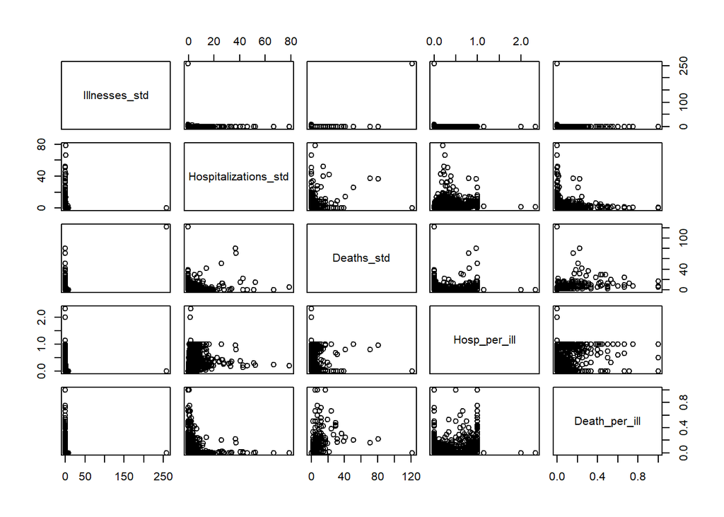

```r
pairs(num_vars)
```

### II. Dimensionality Reduction using Principal Component Analysis

```r
pca_result <- prcomp(num_vars, scale. = TRUE)
summary(pca_result)
```

```
## Importance of components:
##                           PC1    PC2    PC3    PC4     PC5
## Standard deviation     1.3519 1.1092 0.9699 0.8242 0.56753
## Proportion of Variance 0.3655 0.2461 0.1881 0.1359 0.06442
## Cumulative Proportion  0.3655 0.6116 0.7997 0.9356 1.00000
```

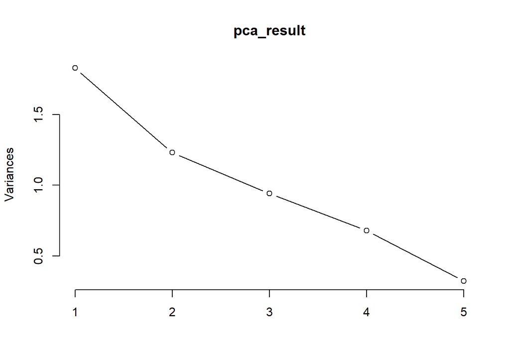

```r
plot(pca_result, type = "l")  # Scree plot
```

Extracted PCA scores

```r
pca_scores <- as.data.frame(pca_result$x[, 1:3])
pca_scores
```

[output not shown]

[output cut: 33320 more lines]

### Apply Clustering Method

#### I. K-Means

```r
set.seed(123)
kmeans_result <- kmeans(pca_scores, centers = 3, nstart = 25)
clean_df$cluster <- factor(kmeans_result$cluster)
```

Visualize

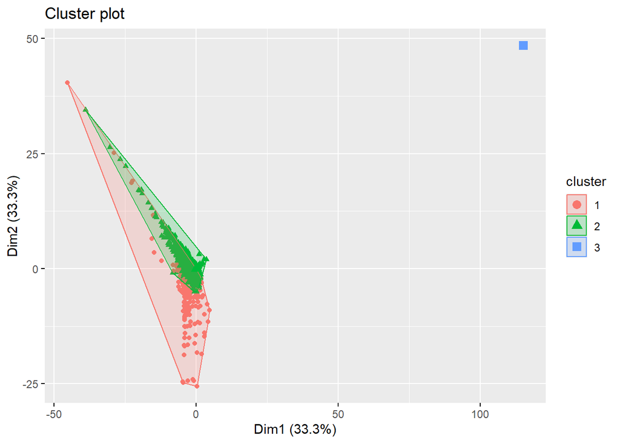

```r
pca_clust <- fviz_cluster(kmeans_result, data = pca_scores, geom = "point", ellipse = TRUE)
pca_clust
```

```r
# Save the plot
ggsave(
  filename = "PCA_kmeans_clusters.png",  # File name and extension
  plot = pca_clust,                      # Plot object to save
  width = 8,                             # Width in inches
  height = 6,                            # Height in inches
  dpi = 300                              # Resolution (good for publication)
)
```

It seems like there is one major outlier. My guess is that it’s the 400,000 illnesses in March 1993 from a water borne outbreak we identified during the EDA.

### Cluster Characterization

#### a. By Numeric Variables

Examine numeric variable summaries

```r
clean_df %>%
  group_by(cluster) %>%
  summarise(across(
    c(Illnesses_std, Hospitalizations_std, Deaths_std, Hosp_per_ill, Death_per_ill),
    mean, na.rm = TRUE
  ))
```

```
## # A tibble: 3 × 6
##   cluster Illnesses_std Hospitalizations_std Deaths_std Hosp_per_ill
##   <fct>           <dbl>                <dbl>      <dbl>        <dbl>
## 1 1            -0.00680               1.90       5.73         0.714
## 2 2            -0.00384              -0.0119    -0.0375       0.0498
## 3 3           258.                   -0.185    122.           0
## # ℹ 1 more variable: Death_per_ill <dbl>
```

It appears the following clusters could be described as follows

- Cluster 1: severe outbreaks
- Cluster 2: mild outbreaks
- Cluster 3: anomaly outbreaks

Now lets compare the outbreaks by categorical variables

#### b. By Most Prevalent Primary Mode

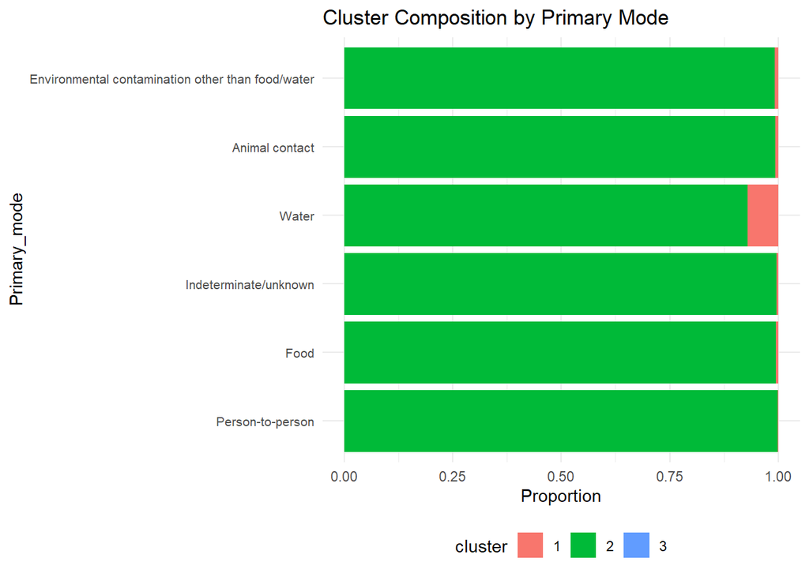

```r
# 1. Identify top primary modes causing illnesses
top_mode <- clean_df %>%
  group_by(Primary_mode) %>%
  summarise(total_illnesses = sum(Illnesses, na.rm = TRUE), .groups = "drop") %>%
  arrange(desc(total_illnesses)) %>%
  pull(Primary_mode)   # <- this is the key fix

# 2. Filter dataset to those Primary_mode
df_top <- clean_df %>%
  filter(Primary_mode %in% top_mode)

# 3. Reorder Primary_mode factor by frequency
df_top <- df_top %>%
  mutate(Primary_mode = forcats::fct_infreq(Primary_mode))

# 4. Plot
ggplot(df_top, aes(x = Primary_mode, fill = cluster)) +
  geom_bar(position = "fill") +
  coord_flip() +
  labs(
    title = "Cluster Composition by Primary Mode",
    y = "Proportion",
    x = "Primary_mode"
  ) +
  theme_minimal() +
  theme(
    legend.position = "bottom",
    axis.text.y = element_text(size = 8)
  )
```

```r
# Save the plot
ggsave(
  filename = "Cluster_by_primary_mode.png",  # File name and extension
  width = 8,                             # Width in inches
  height = 6,                            # Height in inches
  dpi = 300                              # Resolution (good for publication)
)
```

As a table

```r
# Base R version
mode_cluster_tab <- table(clean_df$Primary_mode, clean_df$cluster)
mode_cluster_tab
```

```
##
##                                                         1     2     3
##   Animal contact                                        4   651     0
##   Environmental contamination other than food/water     1   131     0
##   Food                                                131 24598     0
##   Indeterminate/unknown                                19  5658     0
##   Person-to-person                                     37 32377     0
##   Water                                               221  2884     1
```

It appears the following clusters could be described as follows

- Cluster 1: severe outbreaks primarily caused by water borne illness
- Cluster 2: mild outbreaks caused by many modes
- Cluster 3: anomaly outbreaks caused by a water borne illness

#### c. By Most Prevalent Etiologies

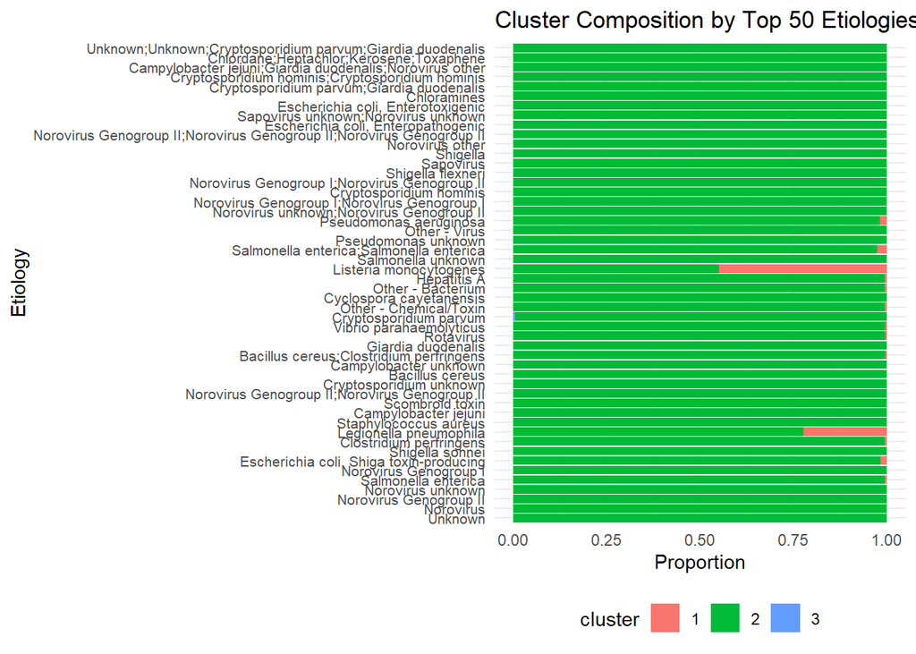

```r
# 1. Identify top 50 etiologies causing illnesses
top_etiologies <- clean_df %>%
  group_by(Etiology) %>%
  summarise(total_illnesses = sum(Illnesses, na.rm = TRUE), .groups = "drop") %>%
  arrange(desc(total_illnesses)) %>%
  slice_head(n = 50) %>%
  pull(Etiology)   # <- this is the key fix

# 2. Filter dataset to those etiologies
df_top <- clean_df %>%
  filter(Etiology %in% top_etiologies)

# 3. Reorder Etiology factor by frequency
df_top <- df_top %>%
  mutate(Etiology = forcats::fct_infreq(Etiology))

# 4. Plot
ggplot(df_top, aes(x = Etiology, fill = cluster)) +
  geom_bar(position = "fill") +
  coord_flip() +
  labs(
    title = "Cluster Composition by Top 50 Etiologies",
    y = "Proportion",
    x = "Etiology"
  ) +
  theme_minimal() +
  theme(
    legend.position = "bottom",
    axis.text.y = element_text(size = 8)
  )
```

```r
# Save the plot
ggsave(
  filename = "Cluster_by_etiology.png",  # File name and extension
  width = 8,                             # Width in inches
  height = 6,                            # Height in inches
  dpi = 300                              # Resolution (good for publication)
)
```

It appears the following clusters could be further described as follows

- Cluster 1: severe outbreaks primarily caused by water borne Listeria and Legionella
- Cluster 2: mild outbreaks caused by many modes with no specific etiology
- Cluster 3: anomaly outbreaks caused by caused by a water borne Cryptosporidium

#### d. By Most Prevalent Settings

[figure not shown]

```r
# 1. Identify top 50 settings causing illnesses
top_settings <- clean_df %>%
  group_by(Setting) %>%
  summarise(total_illnesses = sum(Illnesses, na.rm = TRUE), .groups = "drop") %>%
  arrange(desc(total_illnesses)) %>%
  slice_head(n = 50) %>%
  pull(Setting)   # <- this is the key fix

# 2. Filter dataset to those settings
df_top <- clean_df %>%
  filter(Setting %in% top_settings)

# 3. Reorder Setting factor by frequency
df_top <- df_top %>%
  mutate(Setting = forcats::fct_infreq(Setting))

# 4. Plot
ggplot(df_top, aes(x = Setting, fill = cluster)) +
  geom_bar(position = "fill") +
  coord_flip() +
  labs(
    title = "Cluster Composition by Top 50 Settings",
    y = "Proportion",
    x = "Setting"
  ) +
  theme_minimal() +
  theme(
    legend.position = "bottom",
    axis.text.y = element_text(size = 8)
  )
```

```r
# Save the plot
ggsave(
  filename = "Cluster_by_setting.png",  # File name and extension
  width = 8,                             # Width in inches
  height = 6,                            # Height in inches
  dpi = 300                              # Resolution (good for publication)
)
```

It appears the following clusters could be further described as follows

- Cluster 1: severe outbreaks primarily caused by water borne Listeria and Legionella, spread primarily in Factories/Industrial Facilities or Hospitals
- Cluster 2: mild outbreaks contracted in a variety of modes, with no specific etiology or setting
- Cluster 3: anomaly outbreaks caused by caused by a water borne Cryptosporidium, spread in a community/municipality